**Which NBA teams are best at developing their players?**

Sam Benning

```r
library(tidyverse)
```

```r
library(dplyr)
library(ggplot2)
library(ggrepel)
```

I scraped data from basketball reference, three different data sets from years 2005-2025 - ‘basic’ stats, advanced stats, and each team’s NBA draft history. They are all combined into one file that includes each player’s data from every season they played, with each year as an entry. Their draft data (team, rd, pick, traded), is all included as well.

```r
all_data <- read.csv("https://raw.githubusercontent.com/sbenning7/jour479x_fall_2024/refs/heads/main/presentations/presentation2/all_nba_data_0525.csv")

head(all_data)
```

```
##   X.1 X       Player Age   MP  Rk Team Pos  G GS  PER   TS. X3PAr   FTr ORB.
## 1   1 1 A.J. Hammons  24  163 416  DAL   C 22  0  8.4 0.472 0.238 0.476  5.4
## 2   2 2   A.J. Price  23  865 277  IND  PG 56  2 14.0 0.530 0.492 0.212  1.5
## 3   3 3   A.J. Price  24  795 290  IND  PG 50  0 10.7 0.454 0.466 0.253  2.3
## 4   4 4   A.J. Price  25  568 313  IND  PG 44  1 11.5 0.454 0.506 0.201  2.6
## 5   5 5   A.J. Price  26 1278 220  WAS  PG 57 22 12.4 0.501 0.484 0.150  1.7
## 6   6 6   A.J. Price  27   99 435  MIN  SG 28  0  9.7 0.469 0.478 0.043  1.1
##   DRB. TRB. AST. STL. BLK. TOV. USG.  OWS DWS  WS  WS.48 OBPM DBPM  BPM VORP
## 1 21.0 12.8  3.8  0.3  7.2 16.4 17.6 -0.2 0.2 0.0 -0.001 -6.6  0.0 -6.6 -0.2
## 2  9.7  5.6 20.5  2.0  0.2 13.2 22.7  0.4 0.8 1.2  0.065 -0.1 -0.4 -0.5  0.3
## 3  7.8  5.0 22.7  1.8  0.1 13.0 22.7 -0.4 0.7 0.3  0.020 -1.9 -1.1 -2.9 -0.2
## 4  9.4  6.0 23.9  1.9  0.3 14.5 17.7  0.2 0.5 0.7  0.063 -0.6 -0.5 -1.0  0.1
## 5  8.2  4.9 26.4  1.3  0.2 12.7 18.0  1.0 1.2 2.2  0.084 -0.2 -0.4 -0.6  0.5
## 6 10.2  5.5 21.5  0.5  0.0 13.0 23.2 -0.1 0.0 0.0 -0.012 -2.4 -2.4 -4.8 -0.1
##   Awards Year  FG FGA   FG. X3P X3PA  X3P. X2P X2PA  X2P.  eFG. FT FTA   FT.
```

[output cut: 20 more lines]

First, let’s get all of our old teams back to a combined team. I manually looked through the data just to see this.

```r
# Define team mappings
team_mapping <- c(
  "SEA" = "OKC",  # Seattle SuperSonics to Oklahoma City Thunder
  "NJN" = "BRK",  # New Jersey Nets to Brooklyn Nets
  "CHA" = "CHA",  # Charlotte Hornets (modern franchise)
  "CHO" = "CHA",  # Charlotte Bobcats to Charlotte Hornets
  "NOH" = "NOP",  # New Orleans Hornets to New Orleans Pelicans
  "NOK" = "NOP"   # New Orleans/Oklahoma City Hornets to New Orleans Pelicans
)

# Apply the team mapping to standardize abbreviations
all_data <- all_data |>
  mutate(
    Team = ifelse(Team %in% names(team_mapping), team_mapping[Team], Team),
    Team_Drafted = ifelse(Team_Drafted %in% names(team_mapping), team_mapping[Team_Drafted], Team_Drafted)
  )
```

If we want to take a peek into long term development, we can look at a team’s ability to develop players over time. After doing some thinking, I figured that you could gain a lot of information based upon someone’s rookie PER compared to their peak PER instead of their full career PER (because some players PER tanks at the end of their career).

Let’s see who finds players in the draft who have the highest peak in their career.

```r
long_term_development <- all_data %>%
  group_by(Player, Team_Drafted) %>% filter(G > 10) |>
  summarize(
    rookie_PER = first(PER),
    peak_PER = max(PER, na.rm = TRUE),
    PER_growth = peak_PER - rookie_PER,
  ) %>%
  group_by(Team_Drafted) %>%
  summarize(
    avg_PER_growth = mean(PER_growth, na.rm = TRUE),
  ) %>%
  arrange(desc(avg_PER_growth))
head(long_term_development)
```

```
## # A tibble: 6 × 2
##   Team_Drafted avg_PER_growth
##   <chr>                 <dbl>
## 1 DAL                    5.21
## 2 NOP                    5.02
## 3 CHI                    4.83
## 4 GSW                    4.77
## 5 IND                    4.59
## 6 CLE                    4.50
```

So, Dallas looks like the team that drafts and maybe develops some pretty darn good players. We can look into who their best picks and developments were.

```r
mavs_pd <- all_data %>% filter(Team_Drafted == "DAL") |> group_by(Player, Team_Drafted)|>
  summarize(
    games = sum(G),
    min = sum(MP),
    draftyr = mean(Draft_Yr), #make this an average so that every year of a player's career isn't shown
    lastyr = max(Year), #shows how long a player's career lasted when next to draft year
    traded = mean(Traded), #if a player was traded on draft night
    rookie_PER = first(PER),
    peak_PER = max(PER, na.rm = TRUE),
    PER_growth = peak_PER - rookie_PER,
    ) |>
  arrange(desc(PER_growth))
head(mavs_pd)
```

```
## # A tibble: 6 × 10
## # Groups:   Player [6]
##   Player      Team_Drafted games   min draftyr lastyr traded rookie_PER peak_PER
##   <chr>       <chr>        <int> <int>   <dbl>  <int>  <dbl>      <dbl>    <dbl>
## 1 Byron Mull… DAL            234  3860    2009   2014      1        0.7     16.1
## 2 Tyrell Ter… DAL             13    59    2020   2022      0        6       20
## 3 Solomon Al… DAL             26   181    2010   2012      1        2       14.2
## 4 Tyler Zell… DAL            486  8456    2012   2020      1       11       22.4
## 5 Jalen Brun… DAL            437 12454    2018   2025      0       12.7     23.4
## 6 Mike Musca… DAL            728 11090    2013   2024      1       10.8     19.7
## # ℹ 1 more variable: PER_growth <dbl>
```

So, the Mavericks actually haven’t even had many players who they’ve kept around. They just happened to draft some guys with good potential but unfortunately gave them away.

I will redo the same summary, but can exclude those who were traded on draft night, and players who left a team after a year. That way we can see teams who at least kept their guys around - it shows us more about development.

```r
#to track how long a player stayed with the team that drafted them
all_data <- all_data %>%
  group_by(Player, Team_Drafted) %>%
  mutate(
    years_with_team = sum(Team == Team_Drafted, na.rm = TRUE)  # Count seasons with drafting team
  ) %>%
  ungroup()  # Remove grouping
```

```r
develop <- all_data %>%
  group_by(Player, Team_Drafted) %>% filter(G > 10) |> filter(Traded == 0) |> filter(years_with_team >1) |>
  summarize(
    rookie_PER = first(PER),
    peak_PER = max(PER, na.rm = TRUE),
    PER_growth = peak_PER - rookie_PER,
  ) %>%
  group_by(Team_Drafted) %>%
  summarize(
    avg_PER_growth = mean(PER_growth, na.rm = TRUE),
  ) %>%
  arrange(desc(avg_PER_growth))
head(develop)
```

```
## # A tibble: 6 × 2
##   Team_Drafted avg_PER_growth
##   <chr>                 <dbl>
## 1 GSW                    5.9
## 2 PHO                    5.7
## 3 NOP                    5.66
## 4 OKC                    5.35
## 5 WAS                    5.22
## 6 DAL                    5.1
```

This moves around some of the other teams. Now the Suns and Warriors top our list. The Warriors don’t surprise me, but the Suns do. Let’s look into their data.

```r
suns_pd <- all_data %>% filter(Team_Drafted == "PHO") |> filter(Traded == 0) |> group_by(Player, Team_Drafted)|>
  summarize(
    pick = mean(Pick),
    games = sum(G),
    min = sum(MP),
    draftyr = mean(Draft_Yr), #make this an average so that every year of a player's career isn't shown
    lastyr = max(Year), #shows how long a player's career lasted when next to draft year
    rookie_PER = first(PER),
    peak_PER = max(PER, na.rm = TRUE),
    PER_growth = peak_PER - rookie_PER,
    ) |>
  arrange(desc(PER_growth))
head(suns_pd)
```

```
## # A tibble: 6 × 10
## # Groups:   Player [6]
##   Player       Team_Drafted  pick games   min draftyr lastyr rookie_PER peak_PER
##   <chr>        <chr>        <dbl> <int> <int>   <dbl>  <int>      <dbl>    <dbl>
## 1 Jalen Smith  PHO             10   272  4530    2020   2025        8.4     20.7
## 2 Alex Len     PHO              5   775 13428    2013   2025        7.3     19.4
## 3 Davon Reed   PHO             32   165  1641    2017   2023        4.8     16.7
## 4 Devin Booker PHO             13   614 20942    2015   2025       11.9     22
## 5 Tyler Ennis  PHO             18   272  3335    2014   2018        6.6     14.3
## 6 Robin Lopez  PHO             15   992 20937    2008   2024       11.6     18.9
## # ℹ 1 more variable: PER_growth <dbl>
```

Some notable solid bigs top this list - seems like whoever is developing those guys is doing a good job.

I again decided to filter to include players who have been with a team for >1 year.

```r
#selecting the teams and getting the data
nba_pd <- all_data |> filter(Team_Drafted %in% c("GSW", "DEN", "WAS", "BOS", "BRK", "DET")) %>% filter(Traded == 0) |> filter(G > 10) |> filter(years_with_team >1) |> group_by(Player, Team_Drafted)|>
  summarize(
    pick = mean(Pick),
    games = sum(G),
    min = sum(MP),
    draftyr = mean(Draft_Yr), #make this an average so that every year of a player's career isn't shown
    lastyr = max(Year), #shows how long a player's career lasted when next to draft year
    rookie_PER = first(PER),
    peak_PER = max(PER, na.rm = TRUE),
    PER_growth = peak_PER - rookie_PER,
    )
```

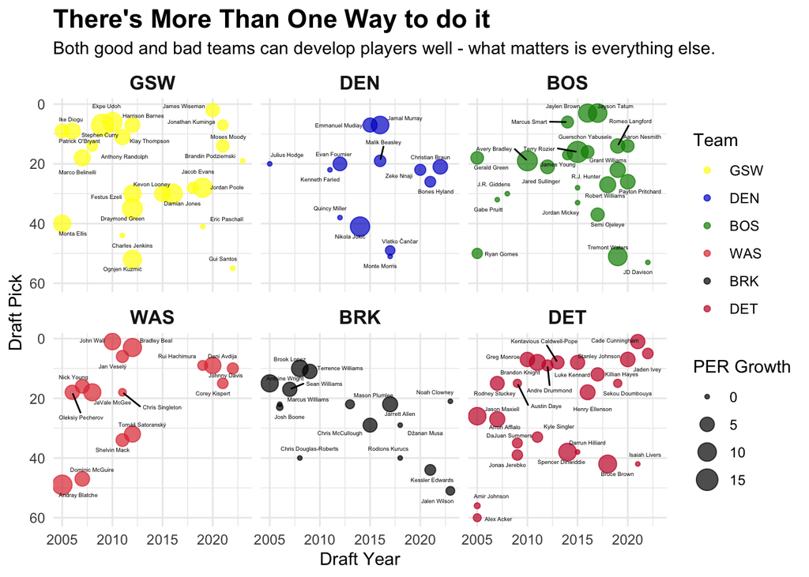

```r
# Define team colors for formatting
team_colors <- c(
  "GSW" = "yellow",
  "DEN" = "blue3",
  "BOS" = "green4",
  "WAS" = "#E03A3E",
  "BRK" = "black",
  "DET" = "#C8102E"
)

# Reorder the Team_Drafted variable for visual
nba_pd <- nba_pd %>%
  mutate(
    Team_Drafted = factor(Team_Drafted, levels = c("GSW", "DEN", "BOS", "WAS", "BRK", "DET"))
  )

# Create the plot
ggplot() +
  geom_point(
    data = nba_pd,
    aes(x = draftyr, y = pick, size = PER_growth, color = Team_Drafted),
    alpha = 0.7
  ) +
  facet_wrap(~Team_Drafted) +
  geom_text_repel(data=nba_pd,
    aes(x=draftyr, y=pick, label=Player), size = 1.25) +
  scale_y_reverse() +
  scale_color_manual(values = team_colors) +  # Use the custom color palette
  labs(
    title = "There's More Than One Way to do it",
    subtitle = "Both good and bad teams can develop players well - what matters is everything else.",
    x = "Draft Year",
    y = "Draft Pick",
    size = "PER Growth",
    color = "Team"
  ) +
  theme_minimal() +
  theme(
    strip.text = element_text(face = "bold", size = 12),  # Bold facet titles
    plot.title = element_text(size = 16, face = "bold"),  # Bold title
    legend.position = "right"
  )
```

For teams like GSW and BOS, the clear picture is that they keep guys around (as seen by their numerous bubbles, showing that many players stay for >1yr) and they do a great job at developing thems. What separates the Warriors is that they seem to “hit” more on their late picks just as much as they do on any other pick, while the Celtics only seem to focus on their lottery guys. Both teams clearly have the recipe for success, though, whatever it may be.

Denver is a bit of an anomaly compared to the other two top teams - their data doesn’t jump out at you to show that they develop players really well. However, for those they they did develop, they really hit. But, during their championship run, they also picked up key pieces in free agency like Aaron Gordon or Bruce Brown. Same with the Celtics (Al Horford and Porzingis).

The conclusion that I come to is that in order to build a top-level team, you need both good drafting and development internally, and roster additions in free agency/trades. I mean, that seems pretty logical to me.

This makes the Warriors franchise truly stand out to me though - they didn’t dip much into other players when they had their dynasty (aside from Durant).

What I believe is a recently bad team, the Brooklyn Nets, see some solid development every once in a while, but really miss big on some players. Whether it is poor drafting or poor development, the decision making across the board for their team internally isn’t great. Thus the reason that they have looked for big-name players in the free agent market, and also the reason that they haven’t succeeded after getting superstars - they don’t have any developed core!

The story with the Pistons and Wizards here is that they are actually decent at player development - their chart doesn’t look much different from GSW/BOS in fact. I think it reflects poor roster management as a reason that they can’t succeed. Off the paper, it is clear that these teams just don’t do well externally.

There could be players who happen to just develop on their own - we want to give players credit for their own hard work, too. I next will look into players who have been on two or more teams in their career and will visualize who has been the best at improving themselves regardless of the team that they are on.